# From pixels to patterns — results and visualisation

Author

Emma Belaud

# Overview

## Role in the pipeline

This is the **final step** of the SEM pipeline, following:

1. `1_database_edition.qmd` — assembles the SEM database
2. `2_SEM_diagnostic.qmd` — selects window duration, transformation, and valid windows
3. `3_SEM_modelisation.qmd` — fits all models and writes result databases

**No modelling is performed here.** Every number in every figure comes directly from pre-computed CSV files. Re-running this script is fast and safe — it never touches a model.

## Input databases

| File | What it contains |
| --- | --- |
| `H1_adjusted_values.csv` | Per-observation null-model residuals with date, land-use label, season |
| `H1_model_summary.csv` | β, SE, t, p, Hedge’s g, R² from the two-step H1 model |
| `DAG_coefficients.csv` | Path coefficients from the full-dataset piecewise SEM |
| `DAG_model_fit.csv` | Fisher’s C, AIC for the full-dataset piecewise SEM |
| `SEM_results_database.csv` | Rolling-window path coefficients for all taxa |
| `indirect_effects.csv` | Rolling-window indirect effect products for all taxa |

## 1. H1 — Direct effect of land-use type on faunal activity

### Two-step modelling approach

Figures in this section show **null-model residuals** — faunal activity with the spatial grouping structure removed.

$$y^* \sim 1 + (1 \mid \text{orientation} / \text{depth}) + \text{AR}(1)$$

The residuals are “leftovers” on the original transformed scale, directly comparable between land-use types without spatial confounding.

**Step 2 — Test the land-use effect on residuals.**

$$\hat{\varepsilon}_{\text{Step 1}} \sim \text{land\_use}$$

β = mean(residuals at C) − mean(residuals at A). A positive β means faunal activity is higher in cultivated plots after removing orientation and depth effects.

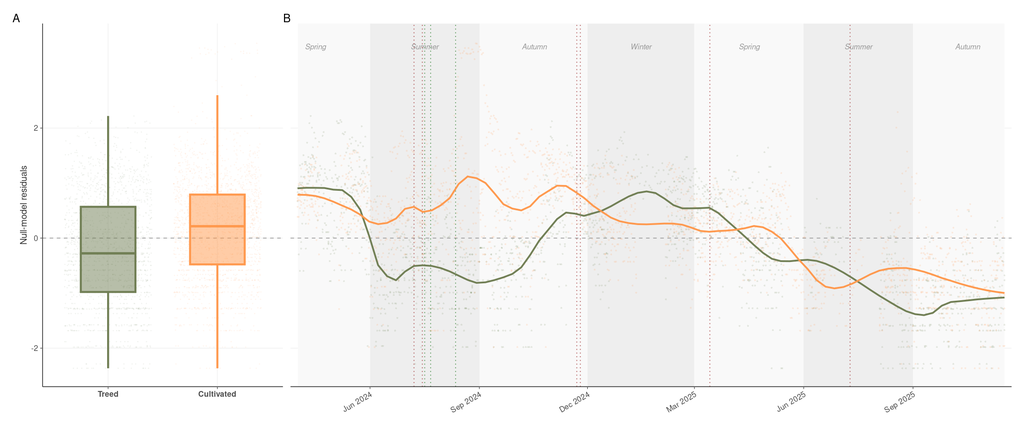

Figure 1: **Figure 1. Direct effect of land-use type on soil invertebrate activity.** (A) Distribution of null-model residuals pooled across the monitoring period. A systematic offset from zero indicates a land-use effect after accounting for scanner orientation and depth. (B) Temporal dynamics of null-model residuals with LOESS smoothers (span = 0.18). Green = treed (A); orange = cultivated (C). Shaded bands = meteorological seasons (Spring: March–May; Summer: June–August; Autumn: September–November; Winter: December–February). Dotted red vertical lines mark key agricultural interventions in the cultivated zone (left to right: wheat harvest, sorghum sowing, sorghum mowing, tillage, chickpea sowing). Dotted green vertical lines mark irrigation events in the cultivated zone.